# Supervised Learning - Foundations Project: ReCell

## Problem Statement

### Business Context

Buying and selling used phones and tablets used to be something that happened on a handful of online marketplace sites. But the used and refurbished device market has grown considerably over the past decade, and a new IDC (International Data Corporation) forecast predicts that the used phone market would be worth \$52.7bn by 2023 with a compound annual growth rate (CAGR) of 13.6% from 2018 to 2023. This growth can be attributed to an uptick in demand for used phones and tablets that offer considerable savings compared with new models.

Refurbished and used devices continue to provide cost-effective alternatives to both consumers and businesses that are looking to save money when purchasing one. There are plenty of other benefits associated with the used device market. Used and refurbished devices can be sold with warranties and can also be insured with proof of purchase. Third-party vendors/platforms, such as Verizon, Amazon, etc., provide attractive offers to customers for refurbished devices. Maximizing the longevity of devices through second-hand trade also reduces their environmental impact and helps in recycling and reducing waste. The impact of the COVID-19 outbreak may further boost this segment as consumers cut back on discretionary spending and buy phones and tablets only for immediate needs.

### Objective

The rising potential of this comparatively under-the-radar market fuels the need for an ML-based solution to develop a dynamic pricing strategy for used and refurbished devices. ReCell, a startup aiming to tap the potential in this market, has hired you as a data scientist. They want you to analyze the data provided and build a linear regression model to predict the price of a used phone/tablet and identify factors that significantly influence it.

### Data Description

The data contains the different attributes of used/refurbished phones and tablets. The data was collected in the year 2021. The detailed data dictionary is given below.

- brand_name: Name of manufacturing brand
- os: OS on which the device runs
- screen_size: Size of the screen in cm
- 4g: Whether 4G is available or not
- 5g: Whether 5G is available or not
- main_camera_mp: Resolution of the rear camera in megapixels
- selfie_camera_mp: Resolution of the front camera in megapixels
- int_memory: Amount of internal memory (ROM) in GB
- ram: Amount of RAM in GB
- battery: Energy capacity of the device battery in mAh
- weight: Weight of the device in grams
- release_year: Year when the device model was released
- days_used: Number of days the used/refurbished device has been used
- normalized_new_price: Normalized price of a new device of the same model in euros
- normalized_used_price: Normalized price of the used/refurbished device in euros

## Importing necessary libraries

```python
#libraries helping with reading and manipulating data
import numpy as np
import pandas as pd
#libraries helping with data visualization
import matplotlib.pyplot as plt
import seaborn as sns

sns.set()

#split the data into train and test
from sklearn.model_selection import train_test_split

#to build a linear regression model
import statsmodels.api as sm

#to build a linear regression model
import statsmodels.api as sm

#to check model performance
from sklearn.metrics import mean_absolute_error, mean_squared_error, r2_score
```

## Loading the dataset

```python
data=pd.read_csv("used_device_data.csv")
```

## Data Overview

- Observations
- Sanity checks

```python
data.head()
```

|  | brand_name | os | screen_size | 4g | 5g | main_camera_mp | selfie_camera_mp | int_memory | ram | battery | weight | release_year | days_used | normalized_used_price | normalized_new_price |
| --- | --- | --- | --- | --- | --- | --- | --- | --- | --- | --- | --- | --- | --- | --- | --- |
| 0 | Honor | Android | 14.50 | yes | no | 13.0 | 5.0 | 64.0 | 3.0 | 3020.0 | 146.0 | 2020 | 127 | 4.307572 | 4.715100 |
| 1 | Honor | Android | 17.30 | yes | yes | 13.0 | 16.0 | 128.0 | 8.0 | 4300.0 | 213.0 | 2020 | 325 | 5.162097 | 5.519018 |
| 2 | Honor | Android | 16.69 | yes | yes | 13.0 | 8.0 | 128.0 | 8.0 | 4200.0 | 213.0 | 2020 | 162 | 5.111084 | 5.884631 |
| 3 | Honor | Android | 25.50 | yes | yes | 13.0 | 8.0 | 64.0 | 6.0 | 7250.0 | 480.0 | 2020 | 345 | 5.135387 | 5.630961 |
| 4 | Honor | Android | 15.32 | yes | no | 13.0 | 8.0 | 64.0 | 3.0 | 5000.0 | 185.0 | 2020 | 293 | 4.389995 | 4.947837 |

```python
data.tail()
```

|  | brand_name | os | screen_size | 4g | 5g | main_camera_mp | selfie_camera_mp | int_memory | ram | battery | weight | release_year | days_used | normalized_used_price | normalized_new_price |
| --- | --- | --- | --- | --- | --- | --- | --- | --- | --- | --- | --- | --- | --- | --- | --- |
| 3449 | Asus | Android | 15.34 | yes | no | NaN | 8.0 | 64.0 | 6.0 | 5000.0 | 190.0 | 2019 | 232 | 4.492337 | 6.483872 |
| 3450 | Asus | Android | 15.24 | yes | no | 13.0 | 8.0 | 128.0 | 8.0 | 4000.0 | 200.0 | 2018 | 541 | 5.037732 | 6.251538 |
| 3451 | Alcatel | Android | 15.80 | yes | no | 13.0 | 5.0 | 32.0 | 3.0 | 4000.0 | 165.0 | 2020 | 201 | 4.357350 | 4.528829 |
| 3452 | Alcatel | Android | 15.80 | yes | no | 13.0 | 5.0 | 32.0 | 2.0 | 4000.0 | 160.0 | 2020 | 149 | 4.349762 | 4.624188 |
| 3453 | Alcatel | Android | 12.83 | yes | no | 13.0 | 5.0 | 16.0 | 2.0 | 4000.0 | 168.0 | 2020 | 176 | 4.132122 | 4.279994 |

```python
data.shape
```

```
(3454, 15)
```

```python
data.describe(include="all").T
```

|  | count | unique | top | freq | mean | std | min | 25% | 50% | 75% | max |
| --- | --- | --- | --- | --- | --- | --- | --- | --- | --- | --- | --- |
| brand_name | 3454 | 34 | Others | 502 | NaN | NaN | NaN | NaN | NaN | NaN | NaN |
| os | 3454 | 4 | Android | 3214 | NaN | NaN | NaN | NaN | NaN | NaN | NaN |
| screen_size | 3454.0 | NaN | NaN | NaN | 13.713115 | 3.80528 | 5.08 | 12.7 | 12.83 | 15.34 | 30.71 |
| 4g | 3454 | 2 | yes | 2335 | NaN | NaN | NaN | NaN | NaN | NaN | NaN |
| 5g | 3454 | 2 | no | 3302 | NaN | NaN | NaN | NaN | NaN | NaN | NaN |
| main_camera_mp | 3275.0 | NaN | NaN | NaN | 9.460208 | 4.815461 | 0.08 | 5.0 | 8.0 | 13.0 | 48.0 |
| selfie_camera_mp | 3452.0 | NaN | NaN | NaN | 6.554229 | 6.970372 | 0.0 | 2.0 | 5.0 | 8.0 | 32.0 |
| int_memory | 3450.0 | NaN | NaN | NaN | 54.573099 | 84.972371 | 0.01 | 16.0 | 32.0 | 64.0 | 1024.0 |
| ram | 3450.0 | NaN | NaN | NaN | 4.036122 | 1.365105 | 0.02 | 4.0 | 4.0 | 4.0 | 12.0 |
| battery | 3448.0 | NaN | NaN | NaN | 3133.402697 | 1299.682844 | 500.0 | 2100.0 | 3000.0 | 4000.0 | 9720.0 |
| weight | 3447.0 | NaN | NaN | NaN | 182.751871 | 88.413228 | 69.0 | 142.0 | 160.0 | 185.0 | 855.0 |
| release_year | 3454.0 | NaN | NaN | NaN | 2015.965258 | 2.298455 | 2013.0 | 2014.0 | 2015.5 | 2018.0 | 2020.0 |
| days_used | 3454.0 | NaN | NaN | NaN | 674.869716 | 248.580166 | 91.0 | 533.5 | 690.5 | 868.75 | 1094.0 |
| normalized_used_price | 3454.0 | NaN | NaN | NaN | 4.364712 | 0.588914 | 1.536867 | 4.033931 | 4.405133 | 4.7557 | 6.619433 |
| normalized_new_price | 3454.0 | NaN | NaN | NaN | 5.233107 | 0.683637 | 2.901422 | 4.790342 | 5.245892 | 5.673718 | 7.847841 |

```python
data.duplicated().sum()
```

```
0
```

```python
data.isnull().sum()
```

```
brand_name                 0
os                         0
screen_size                0
4g                         0
5g                         0
main_camera_mp           179
selfie_camera_mp           2
int_memory                 4
ram                        4
battery                    6
weight                     7
release_year               0
days_used                  0
normalized_used_price      0
normalized_new_price       0
dtype: int64
```

```python
df=data.copy()
```

## Exploratory Data Analysis (EDA)

- EDA is an important part of any project involving data.
- It is important to investigate and understand the data better before building a model with it.
- A few questions have been mentioned below which will help you approach the analysis in the right manner and generate insights from the data.
- A thorough analysis of the data, in addition to the questions mentioned below, should be done.

**Questions**:

1. What does the distribution of normalized used device prices look like?
2. What percentage of the used device market is dominated by Android devices?
3. The amount of RAM is important for the smooth functioning of a device. How does the amount of RAM vary with the brand?
4. A large battery often increases a device's weight, making it feel uncomfortable in the hands. How does the weight vary for phones and tablets offering large batteries (more than 4500 mAh)?
5. Bigger screens are desirable for entertainment purposes as they offer a better viewing experience. How many phones and tablets are available across different brands with a screen size larger than 6 inches?
6. A lot of devices nowadays offer great selfie cameras, allowing us to capture our favorite moments with loved ones. What is the distribution of devices offering greater than 8MP selfie cameras across brands?
7. Which attributes are highly correlated with the normalized price of a used device?

```python
def histogram_boxplot(data, feature, figsize=(15, 10), kde=False, bins=None):
    """
    Boxplot and histogram combined

    data: dataframe
    feature: dataframe column
    figsize: size of figure (default (15,10))
    kde: whether to show the density curve (default False)
    bins: number of bins for histogram (default None)
    """
    f2, (ax_box2, ax_hist2) = plt.subplots(
        nrows=2,  # Number of rows of the subplot grid= 2
        sharex=True,  # x-axis will be shared among all subplots
        gridspec_kw={"height_ratios": (0.25, 0.75)},
        figsize=figsize,
    )  # creating the 2 subplots
    sns.boxplot(
        data=data, x=feature, ax=ax_box2, showmeans=True, color="violet"
    )  # boxplot will be created and a triangle will indicate the mean value of the column
    sns.histplot(
        data=data, x=feature, kde=kde, ax=ax_hist2, bins=bins
    ) if bins else sns.histplot(
        data=data, x=feature, kde=kde, ax=ax_hist2
    )  # For histogram
    ax_hist2.axvline(
        data[feature].mean(), color="green", linestyle="--"
    )  # Add mean to the histogram
    ax_hist2.axvline(
        data[feature].median(), color="black", linestyle="-"
    )  # Add median to the histogram

# function to create labeled barplots


def labeled_barplot(data, feature, perc=False, n=None):
    """
    Barplot with percentage at the top

    data: dataframe
    feature: dataframe column
    perc: whether to display percentages instead of count (default is False)
    n: displays the top n category levels (default is None, i.e., display all levels)
    """

    total = len(data[feature])  # length of the column
    count = data[feature].nunique()
    if n is None:
        plt.figure(figsize=(count + 2, 6))
    else:
        plt.figure(figsize=(n + 2, 6))

    plt.xticks(rotation=90, fontsize=15)
    ax = sns.countplot(
        data=data,
        x=feature,
        palette="Paired",
        order=data[feature].value_counts().index[:n],
    )

    for p in ax.patches:
        if perc == True:
            label = "{:.1f}%".format(
                100 * p.get_height() / total
            )  # percentage of each class of the category
        else:
            label = p.get_height()  # count of each level of the category

        x = p.get_x() + p.get_width() / 2  # width of the plot
        y = p.get_height()  # height of the plot

        ax.annotate(
            label,
            (x, y),
            ha="center",
            va="center",
            size=12,
            xytext=(0, 5),
            textcoords="offset points",
        )  # annotate the percentage

    plt.show()  # show the plot
```

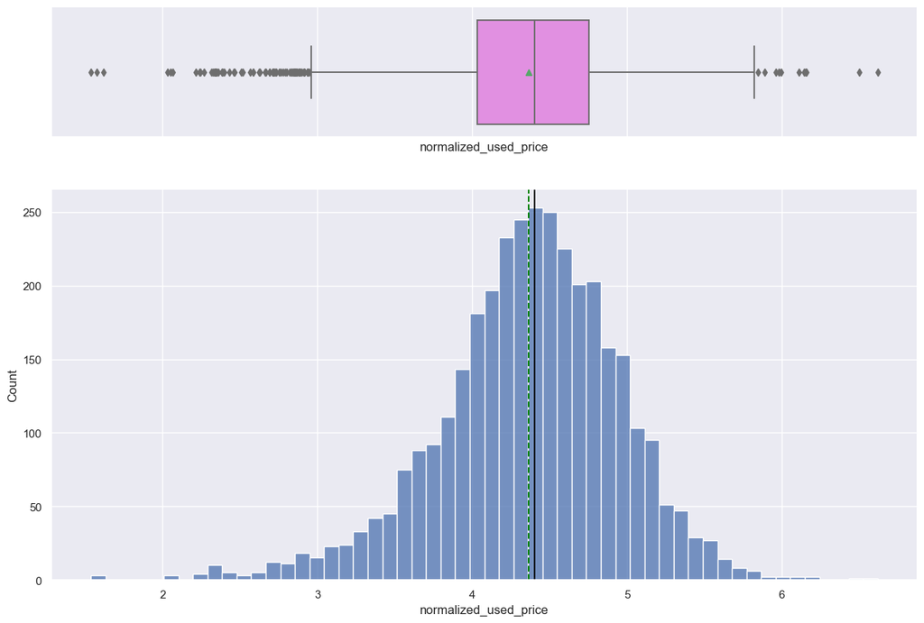

```python
histogram_boxplot(df,"normalized_used_price")
```

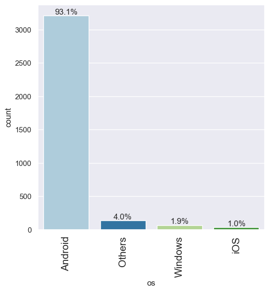

```python
labeled_barplot(df , "os", perc=True)
```

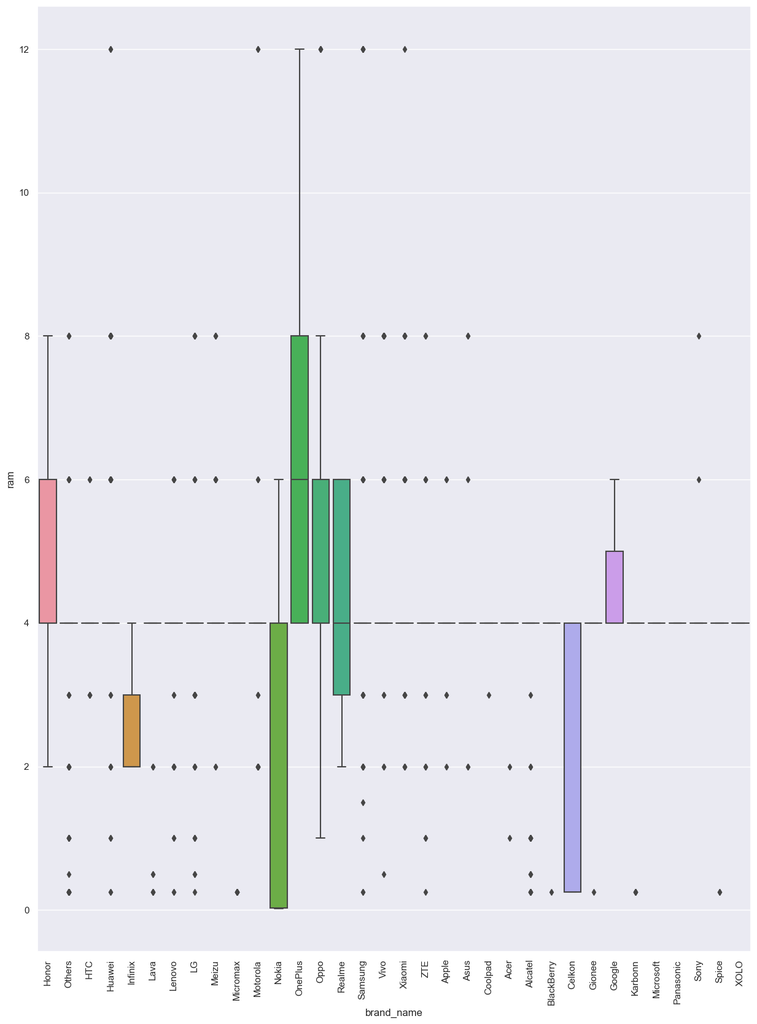

```python
plt.figure(figsize=(15, 20))
sns.boxplot(data=df, x="brand_name",y="ram")
plt.xticks(rotation=90)
plt.show()
```

```python
df_largebatteries=df[df["battery"]>4500]
print(df_largebatteries.shape)
```

```
(341, 15)
```

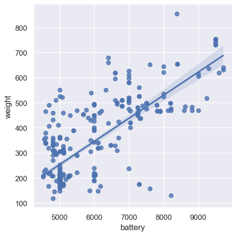

```python
l=sns.lmplot(df_largebatteries,x="battery",y="weight")
plt.show()
```

```python
df_bigscreensize=df[df["screen_size"]>15.24]
print(data_bigscreensize.shape)
```

[output not shown]

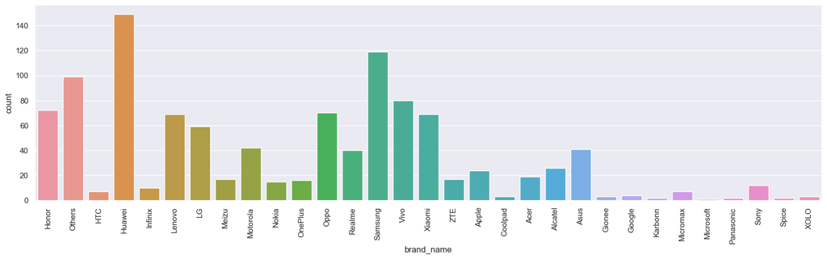

```python
plt.figure(figsize=(20,5))
c=sns.countplot(df_bigscreensize,x="brand_name")
plt.xticks(rotation=90)
plt.show()
```

```python
df_greatselfie=df[df["selfie_camera_mp"]>8]
print(df_greatselfie.shape)
```

```
(655, 15)
```

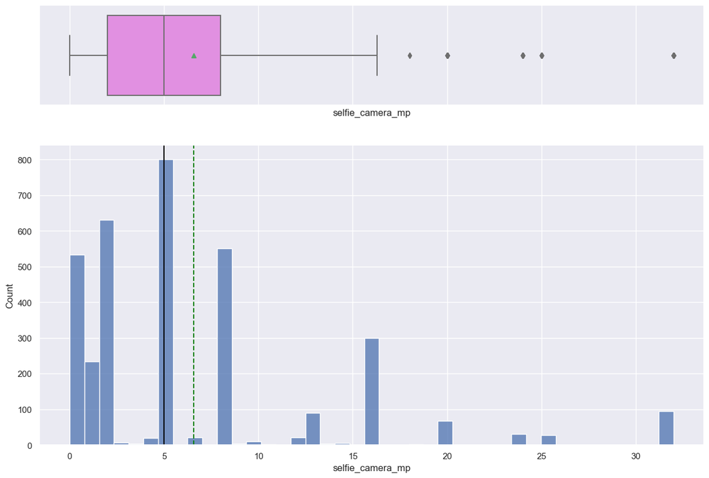

```python
histogram_boxplot(df,"selfie_camera_mp")
```

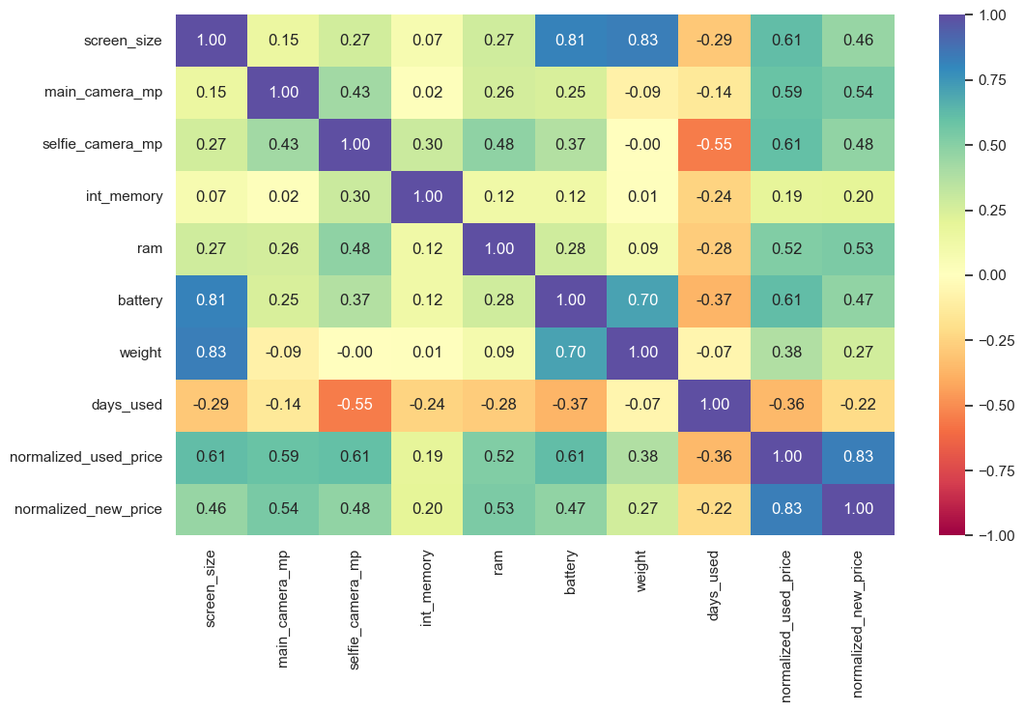

```python
# creating a list of numerical columns
num_cols = df.select_dtypes(include=np.number).columns.tolist()

# dropping release year as it is not numerical in nature
num_cols.remove("release_year")

plt.figure(figsize=(12, 7))
sns.heatmap(df[num_cols].corr(), annot=True, vmin=-1, vmax=1, fmt=".2f", cmap="Spectral")
plt.show()
```

## Data Preprocessing

- Missing value treatment
- Feature engineering (if needed)
- Outlier detection and treatment (if needed)
- Preparing data for modeling
- Any other preprocessing steps (if needed)

```python
df.isnull().sum()
```

```
brand_name                 0
os                         0
screen_size                0
4g                         0
5g                         0
main_camera_mp           179
selfie_camera_mp           2
int_memory                 4
ram                        4
battery                    6
weight                     7
release_year               0
days_used                  0
normalized_used_price      0
normalized_new_price       0
dtype: int64
```

```python
medianFiller = lambda x: x.fillna(x.median())
numeric_columns = df.select_dtypes(include=np.number).columns.tolist()
df[numeric_columns] = df[numeric_columns].apply(medianFiller, axis=0)
```

```python
df.isnull().sum()
```

```
brand_name               0
os                       0
screen_size              0
4g                       0
5g                       0
main_camera_mp           0
selfie_camera_mp         0
int_memory               0
ram                      0
battery                  0
weight                   0
release_year             0
days_used                0
normalized_used_price    0
normalized_new_price     0
dtype: int64
```

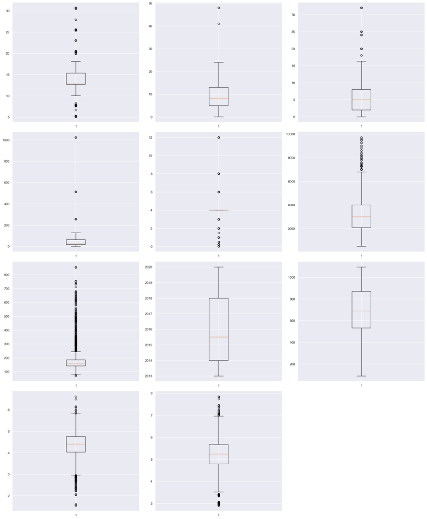

```python
# let's plot the boxplots to check for outliers

plt.figure(figsize=(20, 30))

for i, variable in enumerate(numeric_columns):
    plt.subplot(5,3, i + 1)
    plt.boxplot(data=df, x=variable)
    plt.tight_layout()

plt.show()
```

## EDA

- It is a good idea to explore the data once again after manipulating it.

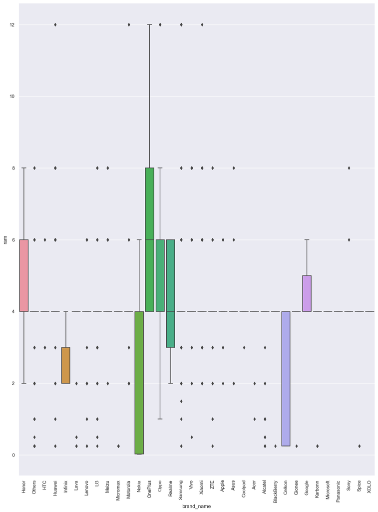

```python
plt.figure(figsize=(15, 20))
sns.boxplot(data=df, x="brand_name",y="ram")
plt.xticks(rotation=90)
plt.show()
```

[output not shown]

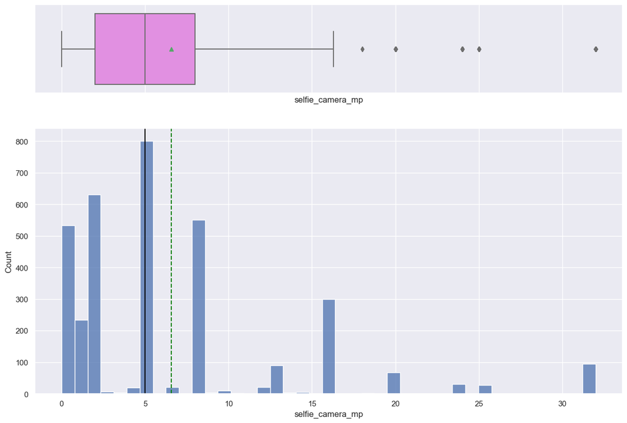

```python
df_greatselfie=df[df["selfie_camera_mp"]>8]
print(df_greatselfie.shape)

histogram_boxplot(df,"selfie_camera_mp")
```

## Model Building - Linear Regression

```python
X = df.drop(["release_year","os","4g","5g"], axis=1) # since year is a temporal variable
y = df["normalized_used_price"]
```

```python
X = pd.get_dummies(X,columns=X.select_dtypes(include=["object", "category"]).columns.tolist(),drop_first=True,)
X.head()
```

|  | screen_size | main_camera_mp | selfie_camera_mp | int_memory | ram | battery | weight | days_used | normalized_used_price | normalized_new_price | ... | brand_name_Others | brand_name_Panasonic | brand_name_Realme | brand_name_Samsung | brand_name_Sony | brand_name_Spice | brand_name_Vivo | brand_name_XOLO | brand_name_Xiaomi | brand_name_ZTE |
| --- | --- | --- | --- | --- | --- | --- | --- | --- | --- | --- | --- | --- | --- | --- | --- | --- | --- | --- | --- | --- | --- |
| 0 | 14.50 | 13.0 | 5.0 | 64.0 | 3.0 | 3020.0 | 146.0 | 127 | 4.307572 | 4.715100 | ... | 0 | 0 | 0 | 0 | 0 | 0 | 0 | 0 | 0 | 0 |
| 1 | 17.30 | 13.0 | 16.0 | 128.0 | 8.0 | 4300.0 | 213.0 | 325 | 5.162097 | 5.519018 | ... | 0 | 0 | 0 | 0 | 0 | 0 | 0 | 0 | 0 | 0 |
| 2 | 16.69 | 13.0 | 8.0 | 128.0 | 8.0 | 4200.0 | 213.0 | 162 | 5.111084 | 5.884631 | ... | 0 | 0 | 0 | 0 | 0 | 0 | 0 | 0 | 0 | 0 |
| 3 | 25.50 | 13.0 | 8.0 | 64.0 | 6.0 | 7250.0 | 480.0 | 345 | 5.135387 | 5.630961 | ... | 0 | 0 | 0 | 0 | 0 | 0 | 0 | 0 | 0 | 0 |
| 4 | 15.32 | 13.0 | 8.0 | 64.0 | 3.0 | 5000.0 | 185.0 | 293 | 4.389995 | 4.947837 | ... | 0 | 0 | 0 | 0 | 0 | 0 | 0 | 0 | 0 | 0 |

5 rows × 43 columns

```python
x_train, x_test, y_train, y_test = train_test_split(X, y, test_size=0.3, random_state=1)
```

```python
x_train = sm.add_constant(x_train)
# adding constant to the test data
x_test = sm.add_constant(x_test)

olsmod0 = sm.OLS(y_train, x_train).fit()
print(olsmod0.summary())
```

```
                              OLS Regression Results
=================================================================================
Dep. Variable:     normalized_used_price   R-squared:                       1.000
Model:                               OLS   Adj. R-squared:                  1.000
Method:                    Least Squares   F-statistic:                 2.524e+26
Date:                   Sat, 05 Aug 2023   Prob (F-statistic):               0.00
Time:                           02:34:05   Log-Likelihood:                 66493.
No. Observations:                   2417   AIC:                        -1.329e+05
Df Residuals:                       2373   BIC:                        -1.326e+05
Df Model:                             43
Covariance Type:               nonrobust
=========================================================================================
                            coef    std err          t      P>|t|      [0.025      0.975]
-----------------------------------------------------------------------------------------
const                 -5.572e-15    8.3e-14     -0.067      0.947   -1.68e-13    1.57e-13
screen_size           -7.264e-17   3.76e-15     -0.019      0.985   -7.44e-15    7.29e-15
main_camera_mp        -4.013e-16    1.8e-15     -0.223      0.824   -3.93e-15    3.13e-15
selfie_camera_mp        1.61e-16    1.3e-15      0.124      0.901   -2.39e-15    2.71e-15
int_memory             1.084e-16   8.13e-17      1.332      0.183   -5.11e-17    2.68e-16
ram                   -6.982e-17   5.32e-15     -0.013      0.990   -1.05e-14    1.04e-14
battery               -1.451e-17    8.3e-18     -1.749      0.080   -3.08e-17    1.76e-18
weight                 2.513e-16   1.48e-16      1.694      0.090   -3.96e-17    5.42e-16
days_used             -3.763e-16   3.02e-17    -12.445      0.000   -4.36e-16   -3.17e-16
normalized_used_price     1.0000    2.4e-14   4.16e+13      0.000       1.000       1.000
normalized_new_price   2.119e-16   1.71e-14      0.012      0.990   -3.34e-14    3.38e-14
brand_name_Alcatel     5.896e-16   5.62e-14      0.010      0.992    -1.1e-13    1.11e-13
brand_name_Apple       1.467e-15   6.92e-14      0.021      0.983   -1.34e-13    1.37e-13
brand_name_Asus        1.852e-15   5.66e-14      0.033      0.974   -1.09e-13    1.13e-13
brand_name_BlackBerry  1.067e-15   8.11e-14      0.013      0.989   -1.58e-13     1.6e-13
brand_name_Celkon     -6.468e-16   7.83e-14     -0.008      0.993   -1.54e-13    1.53e-13
brand_name_Coolpad     7.021e-16   8.59e-14      0.008      0.993   -1.68e-13    1.69e-13
brand_name_Gionee     -4.718e-16   6.85e-14     -0.007      0.995   -1.35e-13    1.34e-13
brand_name_Google     -2.008e-16      1e-13     -0.002      0.998   -1.96e-13    1.96e-13
brand_name_HTC         8.973e-16   5.68e-14      0.016      0.987   -1.11e-13    1.12e-13
brand_name_Honor       1.132e-15    5.8e-14      0.020      0.984   -1.13e-13    1.15e-13
brand_name_Huawei      1.283e-15   5.24e-14      0.024      0.980   -1.02e-13    1.04e-13
brand_name_Infinix    -2.204e-15    1.1e-13     -0.020      0.984   -2.19e-13    2.14e-13
brand_name_Karbonn    -5.165e-16   7.94e-14     -0.007      0.995   -1.56e-13    1.55e-13
brand_name_LG          1.826e-15   5.33e-14      0.034      0.973   -1.03e-13    1.06e-13
brand_name_Lava       -4.893e-16   7.38e-14     -0.007      0.995   -1.45e-13    1.44e-13
```

[output cut: 14 more lines]

```
brand_name_Vivo        1.299e-15   5.73e-14      0.023      0.982   -1.11e-13    1.14e-13
brand_name_XOLO       -2.084e-15   6.49e-14     -0.032      0.974   -1.29e-13    1.25e-13
brand_name_Xiaomi     -1.367e-15   5.69e-14     -0.024      0.981   -1.13e-13     1.1e-13
brand_name_ZTE         1.754e-15   5.58e-14      0.031      0.975   -1.08e-13    1.11e-13
==============================================================================
Omnibus:                      139.561   Durbin-Watson:                   0.228
Prob(Omnibus):                  0.000   Jarque-Bera (JB):               81.530
Skew:                          -0.306   Prob(JB):                     1.98e-18
Kurtosis:                       2.340   Cond. No.                     1.75e+05
==============================================================================

Notes:
[1] Standard Errors assume that the covariance matrix of the errors is correctly specified.
[2] The condition number is large, 1.75e+05. This might indicate that there are
strong multicollinearity or other numerical problems.
```

## Model Performance Check

```python
# function to compute adjusted R-squared
def adj_r2_score(predictors, targets, predictions):
    r2 = r2_score(targets, predictions)
    n = predictors.shape[0]
    k = predictors.shape[1]
    return 1 - ((1 - r2) * (n - 1) / (n - k - 1))


# function to compute MAPE
def mape_score(targets, predictions):
    return np.mean(np.abs(targets - predictions) / targets) * 100


# function to compute different metrics to check performance of a regression model
def model_performance_regression(model, predictors, target):
    """
    Function to compute different metrics to check regression model performance

    model: regressor
    predictors: independent variables
    target: dependent variable
    """

    # predicting using the independent variables
    pred = model.predict(predictors)

    r2 = r2_score(target, pred)  # to compute R-squared
    adjr2 = adj_r2_score(predictors, target, pred)  # to compute adjusted R-squared
    rmse = np.sqrt(mean_squared_error(target, pred))  # to compute RMSE
    mae = mean_absolute_error(target, pred)  # to compute MAE
    mape = mape_score(target, pred)  # to compute MAPE

    # creating a dataframe of metrics
    df_perf = pd.DataFrame(
        {
            "RMSE": rmse,
            "MAE": mae,
            "R-squared": r2,
            "Adj. R-squared": adjr2,
            "MAPE": mape,
        },
        index=[0],
    )

    return df_perf
```

```python
# checking model performance on train set (seen 70% data)
print("Training Performance\n")
olsmodel_train_perf = model_performance_regression(olsmod0,x_train, y_train)
olsmodel_train_perf
```

```
Training Performance
```

|  | RMSE | MAE | R-squared | Adj. R-squared | MAPE |
| --- | --- | --- | --- | --- | --- |
| 0 | 2.729431e-13 | 2.568489e-13 | 1.0 | 1.0 | 6.101282e-12 |

```python
# checking model performance on test set (seen 30% data)
print("Testing Performance\n")
olsmodel_test_perf = model_performance_regression(olsmod0,x_test, y_test)
olsmodel_test_perf
```

```
Testing Performance
```

|  | RMSE | MAE | R-squared | Adj. R-squared | MAPE |
| --- | --- | --- | --- | --- | --- |
| 0 | 2.740051e-13 | 2.583156e-13 | 1.0 | 1.0 | 6.145947e-12 |

## Checking Linear Regression Assumptions

- In order to make statistical inferences from a linear regression model, it is important to ensure that the assumptions of linear regression are satisfied.

```python
from statsmodels.stats.outliers_influence import variance_inflation_factor


def checking_vif(predictors):
    vif = pd.DataFrame()
    vif["feature"] = predictors.columns

    # calculating VIF for each feature
    vif["VIF"] = [
        variance_inflation_factor(predictors.values, i)
        for i in range(len(predictors.columns))
    ]
    return vif
```

```python
checking_vif(x_train)
```

|  | feature | VIF |
| --- | --- | --- |
| 0 | const | 219.691157 |
| 1 | screen_size | 6.634305 |
| 2 | main_camera_mp | 2.329984 |
| 3 | selfie_camera_mp | 2.673893 |
| 4 | int_memory | 1.318491 |
| 5 | ram | 1.719532 |
| 6 | battery | 3.773690 |
| 7 | weight | 5.623524 |
| 8 | days_used | 1.815566 |
| 9 | normalized_used_price | 6.271187 |
| 10 | normalized_new_price | 4.318319 |
| 11 | brand_name_Alcatel | 3.373330 |
| 12 | brand_name_Apple | 2.056997 |
| 13 | brand_name_Asus | 3.310723 |
| 14 | brand_name_BlackBerry | 1.546938 |
| 15 | brand_name_Celkon | 1.759649 |
| 16 | brand_name_Coolpad | 1.448731 |
| 17 | brand_name_Gionee | 1.949936 |
| 18 | brand_name_Google | 1.311387 |
| 19 | brand_name_HTC | 3.373638 |
| 20 | brand_name_Honor | 3.309137 |
| 21 | brand_name_Huawei | 5.915712 |
| 22 | brand_name_Infinix | 1.279529 |
| 23 | brand_name_Karbonn | 1.565713 |
| 24 | brand_name_LG | 4.772243 |
| 25 | brand_name_Lava | 1.706072 |
| 26 | brand_name_Lenovo | 4.532834 |
| 27 | brand_name_Meizu | 2.155980 |
| 28 | brand_name_Micromax | 3.358740 |
| 29 | brand_name_Microsoft | 1.381508 |
| 30 | brand_name_Motorola | 3.235758 |
| 31 | brand_name_Nokia | 3.198448 |
| 32 | brand_name_OnePlus | 1.421872 |
| 33 | brand_name_Oppo | 3.932714 |
| 34 | brand_name_Others | 9.661405 |
| 35 | brand_name_Panasonic | 2.087606 |
| 36 | brand_name_Realme | 1.915219 |
| 37 | brand_name_Samsung | 7.428968 |
| 38 | brand_name_Sony | 2.918860 |
| 39 | brand_name_Spice | 1.680266 |
| 40 | brand_name_Vivo | 3.626398 |
| 41 | brand_name_XOLO | 2.129575 |
| 42 | brand_name_Xiaomi | 3.694326 |
| 43 | brand_name_ZTE | 3.742073 |

```python
def treating_multicollinearity(predictors, target, high_vif_columns):
    """
    Checking the effect of dropping the columns showing high multicollinearity
    on model performance (adj. R-squared and RMSE)

    predictors: independent variables
    target: dependent variable
    high_vif_columns: columns having high VIF
    """
    # empty lists to store adj. R-squared and RMSE values
    adj_r2 = []
    rmse = []

    # build ols models by dropping one of the high VIF columns at a time
    # store the adjusted R-squared and RMSE in the lists defined previously
    for cols in high_vif_columns:
        # defining the new train set
        train = predictors.loc[:, ~predictors.columns.str.startswith(cols)]

        # create the model
        olsmodel = sm.OLS(target, train).fit()

        # adding adj. R-squared and RMSE to the lists
        adj_r2.append(olsmodel.rsquared_adj)
        rmse.append(np.sqrt(olsmodel.mse_resid))

    # creating a dataframe for the results
    temp = pd.DataFrame(
        {
            "col": high_vif_columns,
            "Adj. R-squared after_dropping col": adj_r2,
            "RMSE after dropping col": rmse,
        }
    ).sort_values(by="Adj. R-squared after_dropping col", ascending=False)
    temp.reset_index(drop=True, inplace=True)

    return temp
```

## Final Model

```python
x_train = sm.add_constant(x_train)
# adding constant to the test data
x_test = sm.add_constant(x_test)

olsmod0 = sm.OLS(y_train, x_train).fit()
print(olsmod0.summary())
```

```
                              OLS Regression Results
=================================================================================
Dep. Variable:     normalized_used_price   R-squared:                       1.000
Model:                               OLS   Adj. R-squared:                  1.000
Method:                    Least Squares   F-statistic:                 2.524e+26
Date:                   Sat, 05 Aug 2023   Prob (F-statistic):               0.00
Time:                           02:53:42   Log-Likelihood:                 66493.
No. Observations:                   2417   AIC:                        -1.329e+05
Df Residuals:                       2373   BIC:                        -1.326e+05
Df Model:                             43
Covariance Type:               nonrobust
=========================================================================================
                            coef    std err          t      P>|t|      [0.025      0.975]
-----------------------------------------------------------------------------------------
const                 -5.572e-15    8.3e-14     -0.067      0.947   -1.68e-13    1.57e-13
screen_size           -7.264e-17   3.76e-15     -0.019      0.985   -7.44e-15    7.29e-15
main_camera_mp        -4.013e-16    1.8e-15     -0.223      0.824   -3.93e-15    3.13e-15
selfie_camera_mp        1.61e-16    1.3e-15      0.124      0.901   -2.39e-15    2.71e-15
int_memory             1.084e-16   8.13e-17      1.332      0.183   -5.11e-17    2.68e-16
ram                   -6.982e-17   5.32e-15     -0.013      0.990   -1.05e-14    1.04e-14
battery               -1.451e-17    8.3e-18     -1.749      0.080   -3.08e-17    1.76e-18
weight                 2.513e-16   1.48e-16      1.694      0.090   -3.96e-17    5.42e-16
days_used             -3.763e-16   3.02e-17    -12.445      0.000   -4.36e-16   -3.17e-16
normalized_used_price     1.0000    2.4e-14   4.16e+13      0.000       1.000       1.000
normalized_new_price   2.119e-16   1.71e-14      0.012      0.990   -3.34e-14    3.38e-14
brand_name_Alcatel     5.896e-16   5.62e-14      0.010      0.992    -1.1e-13    1.11e-13
brand_name_Apple       1.467e-15   6.92e-14      0.021      0.983   -1.34e-13    1.37e-13
brand_name_Asus        1.852e-15   5.66e-14      0.033      0.974   -1.09e-13    1.13e-13
brand_name_BlackBerry  1.067e-15   8.11e-14      0.013      0.989   -1.58e-13     1.6e-13
brand_name_Celkon     -6.468e-16   7.83e-14     -0.008      0.993   -1.54e-13    1.53e-13
brand_name_Coolpad     7.021e-16   8.59e-14      0.008      0.993   -1.68e-13    1.69e-13
brand_name_Gionee     -4.718e-16   6.85e-14     -0.007      0.995   -1.35e-13    1.34e-13
brand_name_Google     -2.008e-16      1e-13     -0.002      0.998   -1.96e-13    1.96e-13
brand_name_HTC         8.973e-16   5.68e-14      0.016      0.987   -1.11e-13    1.12e-13
brand_name_Honor       1.132e-15    5.8e-14      0.020      0.984   -1.13e-13    1.15e-13
brand_name_Huawei      1.283e-15   5.24e-14      0.024      0.980   -1.02e-13    1.04e-13
brand_name_Infinix    -2.204e-15    1.1e-13     -0.020      0.984   -2.19e-13    2.14e-13
brand_name_Karbonn    -5.165e-16   7.94e-14     -0.007      0.995   -1.56e-13    1.55e-13
brand_name_LG          1.826e-15   5.33e-14      0.034      0.973   -1.03e-13    1.06e-13
brand_name_Lava       -4.893e-16   7.38e-14     -0.007      0.995   -1.45e-13    1.44e-13
```

[output cut: 14 more lines]

```
brand_name_Vivo        1.299e-15   5.73e-14      0.023      0.982   -1.11e-13    1.14e-13
brand_name_XOLO       -2.084e-15   6.49e-14     -0.032      0.974   -1.29e-13    1.25e-13
brand_name_Xiaomi     -1.367e-15   5.69e-14     -0.024      0.981   -1.13e-13     1.1e-13
brand_name_ZTE         1.754e-15   5.58e-14      0.031      0.975   -1.08e-13    1.11e-13
==============================================================================
Omnibus:                      139.561   Durbin-Watson:                   0.228
Prob(Omnibus):                  0.000   Jarque-Bera (JB):               81.530
Skew:                          -0.306   Prob(JB):                     1.98e-18
Kurtosis:                       2.340   Cond. No.                     1.75e+05
==============================================================================

Notes:
[1] Standard Errors assume that the covariance matrix of the errors is correctly specified.
[2] The condition number is large, 1.75e+05. This might indicate that there are
strong multicollinearity or other numerical problems.
```